# Risk Factor Analysis

## Outcome Variable

**Outcome Variable:** ever_stunted

## Predictor Variables

**Intervention Variable:** nhh

**Adjustment Set:**

- arm
- W_mage
- meducyrs
- feducyrs
- W_mhtcm
- W_mwtkg
- W_mbmi
- W_nrooms
- impfloor
- impsan
- safeh20
- delta_W_mage
- delta_meducyrs
- delta_feducyrs
- delta_W_mhtcm
- delta_W_mwtkg
- delta_W_mbmi
- delta_W_nrooms
- delta_impfloor
- delta_impsan
- delta_safeh20

## Stratifying Variables

The analysis was stratified on these variable(s):

- agecat
- studyid
- country

## Data Summary

| agecat | studyid | country | nhh | ever_stunted | n_cell | n |
| --- | --- | --- | --- | --- | --- | --- |
| 0-6 months | ki1000108-IRC | INDIA | 3 or less | 0 | 54 | 410 |
| 0-6 months | ki1000108-IRC | INDIA | 3 or less | 1 | 4 | 410 |
| 0-6 months | ki1000108-IRC | INDIA | 4-5 | 0 | 135 | 410 |
| 0-6 months | ki1000108-IRC | INDIA | 4-5 | 1 | 23 | 410 |
| 0-6 months | ki1000108-IRC | INDIA | 6-7 | 0 | 92 | 410 |
| 0-6 months | ki1000108-IRC | INDIA | 6-7 | 1 | 15 | 410 |
| 0-6 months | ki1000108-IRC | INDIA | 8+ | 0 | 79 | 410 |
| 0-6 months | ki1000108-IRC | INDIA | 8+ | 1 | 8 | 410 |
| 0-6 months | ki1000304b-SAS-FoodSuppl | INDIA | 3 or less | 0 | 26 | 416 |
| 0-6 months | ki1000304b-SAS-FoodSuppl | INDIA | 3 or less | 1 | 12 | 416 |
| 0-6 months | ki1000304b-SAS-FoodSuppl | INDIA | 4-5 | 0 | 110 | 416 |
| 0-6 months | ki1000304b-SAS-FoodSuppl | INDIA | 4-5 | 1 | 72 | 416 |
| 0-6 months | ki1000304b-SAS-FoodSuppl | INDIA | 6-7 | 0 | 79 | 416 |
| 0-6 months | ki1000304b-SAS-FoodSuppl | INDIA | 6-7 | 1 | 47 | 416 |
| 0-6 months | ki1000304b-SAS-FoodSuppl | INDIA | 8+ | 0 | 42 | 416 |
| 0-6 months | ki1000304b-SAS-FoodSuppl | INDIA | 8+ | 1 | 28 | 416 |
| 0-6 months | ki1017093-NIH-Birth | BANGLADESH | 3 or less | 0 | 98 | 629 |
| 0-6 months | ki1017093-NIH-Birth | BANGLADESH | 3 or less | 1 | 19 | 629 |
| 0-6 months | ki1017093-NIH-Birth | BANGLADESH | 4-5 | 0 | 221 | 629 |
| 0-6 months | ki1017093-NIH-Birth | BANGLADESH | 4-5 | 1 | 43 | 629 |
| 0-6 months | ki1017093-NIH-Birth | BANGLADESH | 6-7 | 0 | 122 | 629 |
| 0-6 months | ki1017093-NIH-Birth | BANGLADESH | 6-7 | 1 | 20 | 629 |
| 0-6 months | ki1017093-NIH-Birth | BANGLADESH | 8+ | 0 | 89 | 629 |
| 0-6 months | ki1017093-NIH-Birth | BANGLADESH | 8+ | 1 | 17 | 629 |
| 0-6 months | ki1017093b-PROVIDE | BANGLADESH | 3 or less | 0 | 131 | 700 |
| 0-6 months | ki1017093b-PROVIDE | BANGLADESH | 3 or less | 1 | 9 | 700 |
| 0-6 months | ki1017093b-PROVIDE | BANGLADESH | 4-5 | 0 | 286 | 700 |
| 0-6 months | ki1017093b-PROVIDE | BANGLADESH | 4-5 | 1 | 36 | 700 |
| 0-6 months | ki1017093b-PROVIDE | BANGLADESH | 6-7 | 0 | 137 | 700 |
| 0-6 months | ki1017093b-PROVIDE | BANGLADESH | 6-7 | 1 | 14 | 700 |

[output cut: 114 more lines]

The following strata were considered:

- agecat: 0-24 months, studyid: ki1000108-IRC, country: INDIA
- agecat: 0-24 months, studyid: ki1000304b-SAS-FoodSuppl, country: INDIA
- agecat: 0-24 months, studyid: ki1017093-NIH-Birth, country: BANGLADESH
- agecat: 0-24 months, studyid: ki1017093b-PROVIDE, country: BANGLADESH
- agecat: 0-24 months, studyid: ki1017093c-NIH-Crypto, country: BANGLADESH
- agecat: 0-24 months, studyid: ki1148112-LCNI-5, country: MALAWI
- agecat: 0-6 months, studyid: ki1000108-IRC, country: INDIA
- agecat: 0-6 months, studyid: ki1000304b-SAS-FoodSuppl, country: INDIA
- agecat: 0-6 months, studyid: ki1017093-NIH-Birth, country: BANGLADESH
- agecat: 0-6 months, studyid: ki1017093b-PROVIDE, country: BANGLADESH
- agecat: 0-6 months, studyid: ki1017093c-NIH-Crypto, country: BANGLADESH
- agecat: 0-6 months, studyid: ki1148112-LCNI-5, country: MALAWI
- agecat: 6-24 months, studyid: ki1000108-IRC, country: INDIA
- agecat: 6-24 months, studyid: ki1000304b-SAS-FoodSuppl, country: INDIA
- agecat: 6-24 months, studyid: ki1017093-NIH-Birth, country: BANGLADESH
- agecat: 6-24 months, studyid: ki1017093b-PROVIDE, country: BANGLADESH
- agecat: 6-24 months, studyid: ki1017093c-NIH-Crypto, country: BANGLADESH
- agecat: 6-24 months, studyid: ki1148112-LCNI-5, country: MALAWI

### Dropped Strata

Some strata were dropped due to rare outcomes:

- agecat: 0-6 months, studyid: ki1000108-IRC, country: INDIA
- agecat: 0-6 months, studyid: ki1148112-LCNI-5, country: MALAWI

## Methods Detail

We’re interested in the causal parameters $E[Y_a]$ for all values of $a \in \mathcal{A}$. These parameters represent the mean outcome if, possibly contrary to fact, we intervened to set all units to have $A=a$. Under the randomization and positivity assumptions, these are identified by the statistical parameters $\psi_a=E_W[E_{Y|A,W}(Y|A=a,W)]$. In addition, we’re interested in the mean of $Y$, $E[Y]$ under no intervention (the observed mean). We will estimate these parameters by using SuperLearner to fit the relevant likelihood factors – $E_{Y|A,W}(Y|A=a,W)$ and $p(A=a|W)$, and then updating our likelihood fit using a joint TMLE.

For unadjusted analyses ($W=\{\}$), initial likelihoods were estimated using Lrnr_glm to estimate the simple $E(Y|A)$ and Lrnr_mean to estimate $p(A)$. For adjusted analyses, a small library containing Lrnr_glmnet, Lrnr_xgboost, and Lrnr_mean was used.

Having estimated these parameters, we will then use the delta method to estimate relative risks and attributable risks relative to a prespecified baseline level of $A$.

# Results Detail

## Results Plots

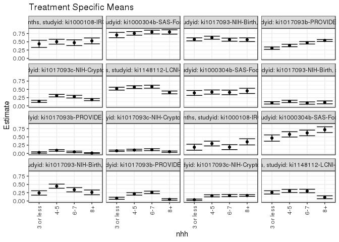

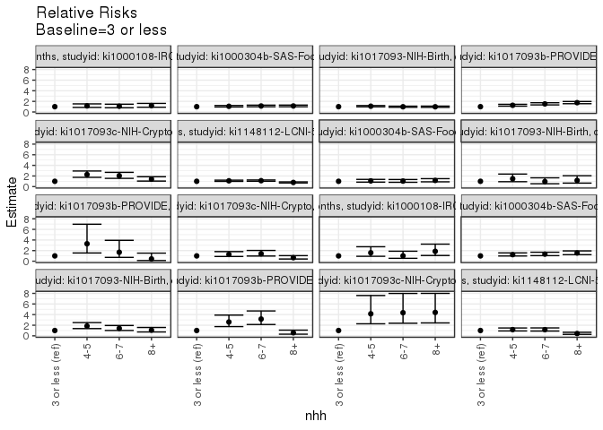

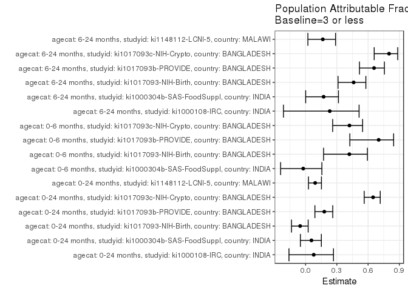

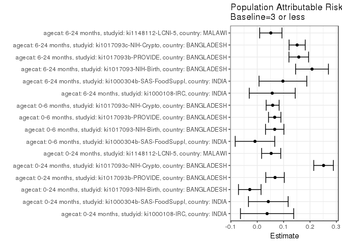

## Results Table

### Parameter: TSM

| agecat | studyid | country | intervention_level | baseline_level | estimate | ci_lower | ci_upper |
| --- | --- | --- | --- | --- | --- | --- | --- |
| 0-24 months | ki1000108-IRC | INDIA | 3 or less | NA | 0.4383069 | 0.3295592 | 0.5470545 |
| 0-24 months | ki1000108-IRC | INDIA | 4-5 | NA | 0.5025987 | 0.4291578 | 0.5760396 |
| 0-24 months | ki1000108-IRC | INDIA | 6-7 | NA | 0.4726981 | 0.3866547 | 0.5587416 |
| 0-24 months | ki1000108-IRC | INDIA | 8+ | NA | 0.5273132 | 0.4389892 | 0.6156372 |
| 0-24 months | ki1000304b-SAS-FoodSuppl | INDIA | 3 or less | NA | 0.7044837 | 0.6234331 | 0.7855343 |
| 0-24 months | ki1000304b-SAS-FoodSuppl | INDIA | 4-5 | NA | 0.7547428 | 0.7005781 | 0.8089075 |
| 0-24 months | ki1000304b-SAS-FoodSuppl | INDIA | 6-7 | NA | 0.7946338 | 0.7372143 | 0.8520532 |
| 0-24 months | ki1000304b-SAS-FoodSuppl | INDIA | 8+ | NA | 0.7974132 | 0.7323682 | 0.8624583 |
| 0-24 months | ki1017093-NIH-Birth | BANGLADESH | 3 or less | NA | 0.5737003 | 0.5272466 | 0.6201540 |
| 0-24 months | ki1017093-NIH-Birth | BANGLADESH | 4-5 | NA | 0.6243292 | 0.5788700 | 0.6697884 |
| 0-24 months | ki1017093-NIH-Birth | BANGLADESH | 6-7 | NA | 0.5653496 | 0.5190466 | 0.6116527 |
| 0-24 months | ki1017093-NIH-Birth | BANGLADESH | 8+ | NA | 0.5637017 | 0.5079079 | 0.6194956 |
| 0-24 months | ki1017093b-PROVIDE | BANGLADESH | 3 or less | NA | 0.3082477 | 0.2734893 | 0.3430061 |
| 0-24 months | ki1017093b-PROVIDE | BANGLADESH | 4-5 | NA | 0.3885732 | 0.3509132 | 0.4262333 |
| 0-24 months | ki1017093b-PROVIDE | BANGLADESH | 6-7 | NA | 0.4698371 | 0.4319968 | 0.5076774 |
| 0-24 months | ki1017093b-PROVIDE | BANGLADESH | 8+ | NA | 0.5406048 | 0.5119216 | 0.5692881 |
| 0-24 months | ki1017093c-NIH-Crypto | BANGLADESH | 3 or less | NA | 0.1365258 | 0.1044793 | 0.1685723 |
| 0-24 months | ki1017093c-NIH-Crypto | BANGLADESH | 4-5 | NA | 0.3093223 | 0.2718621 | 0.3467825 |
| 0-24 months | ki1017093c-NIH-Crypto | BANGLADESH | 6-7 | NA | 0.2784314 | 0.2373147 | 0.3195481 |
| 0-24 months | ki1017093c-NIH-Crypto | BANGLADESH | 8+ | NA | 0.1899027 | 0.1583127 | 0.2214928 |
| 0-24 months | ki1148112-LCNI-5 | MALAWI | 3 or less | NA | 0.5200588 | 0.4760109 | 0.5641066 |
| 0-24 months | ki1148112-LCNI-5 | MALAWI | 4-5 | NA | 0.5671779 | 0.5256821 | 0.6086737 |
| 0-24 months | ki1148112-LCNI-5 | MALAWI | 6-7 | NA | 0.5792623 | 0.5341533 | 0.6243713 |
| 0-24 months | ki1148112-LCNI-5 | MALAWI | 8+ | NA | 0.4069057 | 0.3643657 | 0.4494458 |
| 0-6 months | ki1000304b-SAS-FoodSuppl | INDIA | 3 or less | NA | 0.3908421 | 0.3162570 | 0.4654272 |
| 0-6 months | ki1000304b-SAS-FoodSuppl | INDIA | 4-5 | NA | 0.4179536 | 0.3554626 | 0.4804446 |
| 0-6 months | ki1000304b-SAS-FoodSuppl | INDIA | 6-7 | NA | 0.4072555 | 0.3386667 | 0.4758443 |
| 0-6 months | ki1000304b-SAS-FoodSuppl | INDIA | 8+ | NA | 0.4535069 | 0.3741499 | 0.5328640 |
| 0-6 months | ki1017093-NIH-Birth | BANGLADESH | 3 or less | NA | 0.0912742 | 0.0552992 | 0.1272492 |
| 0-6 months | ki1017093-NIH-Birth | BANGLADESH | 4-5 | NA | 0.1346662 | 0.0994064 | 0.1699260 |
| 0-6 months | ki1017093-NIH-Birth | BANGLADESH | 6-7 | NA | 0.0861733 | 0.0513759 | 0.1209707 |
| 0-6 months | ki1017093-NIH-Birth | BANGLADESH | 8+ | NA | 0.1058614 | 0.0624500 | 0.1492727 |
| 0-6 months | ki1017093b-PROVIDE | BANGLADESH | 3 or less | NA | 0.0281429 | 0.0083690 | 0.0479167 |
| 0-6 months | ki1017093b-PROVIDE | BANGLADESH | 4-5 | NA | 0.0925212 | 0.0677018 | 0.1173406 |
| 0-6 months | ki1017093b-PROVIDE | BANGLADESH | 6-7 | NA | 0.0475714 | 0.0251030 | 0.0700397 |
| 0-6 months | ki1017093b-PROVIDE | BANGLADESH | 8+ | NA | 0.0122511 | -0.0003864 | 0.0248887 |
| 0-6 months | ki1017093c-NIH-Crypto | BANGLADESH | 3 or less | NA | 0.0801698 | 0.0590823 | 0.1012572 |
| 0-6 months | ki1017093c-NIH-Crypto | BANGLADESH | 4-5 | NA | 0.1018110 | 0.0769833 | 0.1266387 |
| 0-6 months | ki1017093c-NIH-Crypto | BANGLADESH | 6-7 | NA | 0.1128088 | 0.0833155 | 0.1423021 |
| 0-6 months | ki1017093c-NIH-Crypto | BANGLADESH | 8+ | NA | 0.0529978 | 0.0326267 | 0.0733689 |
| 6-24 months | ki1000108-IRC | INDIA | 3 or less | NA | 0.1880178 | 0.0973650 | 0.2786706 |
| 6-24 months | ki1000108-IRC | INDIA | 4-5 | NA | 0.2987906 | 0.2261149 | 0.3714664 |
| 6-24 months | ki1000108-IRC | INDIA | 6-7 | NA | 0.1904335 | 0.1157210 | 0.2651460 |
| 6-24 months | ki1000108-IRC | INDIA | 8+ | NA | 0.3501123 | 0.2573198 | 0.4429048 |
| 6-24 months | ki1000304b-SAS-FoodSuppl | INDIA | 3 or less | NA | 0.4647037 | 0.3697188 | 0.5596886 |
| 6-24 months | ki1000304b-SAS-FoodSuppl | INDIA | 4-5 | NA | 0.5759431 | 0.4959900 | 0.6558962 |
| 6-24 months | ki1000304b-SAS-FoodSuppl | INDIA | 6-7 | NA | 0.6194771 | 0.5332484 | 0.7057057 |
| 6-24 months | ki1000304b-SAS-FoodSuppl | INDIA | 8+ | NA | 0.7180343 | 0.6307646 | 0.8053039 |
| 6-24 months | ki1017093-NIH-Birth | BANGLADESH | 3 or less | NA | 0.2424287 | 0.1764249 | 0.3084326 |
| 6-24 months | ki1017093-NIH-Birth | BANGLADESH | 4-5 | NA | 0.4471003 | 0.3848280 | 0.5093726 |
| 6-24 months | ki1017093-NIH-Birth | BANGLADESH | 6-7 | NA | 0.3398611 | 0.2755483 | 0.4041740 |
| 6-24 months | ki1017093-NIH-Birth | BANGLADESH | 8+ | NA | 0.2597587 | 0.1870576 | 0.3324599 |
| 6-24 months | ki1017093b-PROVIDE | BANGLADESH | 3 or less | NA | 0.0820800 | 0.0510789 | 0.1130810 |
| 6-24 months | ki1017093b-PROVIDE | BANGLADESH | 4-5 | NA | 0.2137273 | 0.1760716 | 0.2513830 |
| 6-24 months | ki1017093b-PROVIDE | BANGLADESH | 6-7 | NA | 0.2594589 | 0.2216217 | 0.2972962 |
| 6-24 months | ki1017093b-PROVIDE | BANGLADESH | 8+ | NA | 0.0471597 | 0.0234457 | 0.0708737 |
| 6-24 months | ki1017093c-NIH-Crypto | BANGLADESH | 3 or less | NA | 0.0375014 | 0.0158089 | 0.0591938 |
| 6-24 months | ki1017093c-NIH-Crypto | BANGLADESH | 4-5 | NA | 0.1555992 | 0.1241847 | 0.1870138 |
| 6-24 months | ki1017093c-NIH-Crypto | BANGLADESH | 6-7 | NA | 0.1633350 | 0.1292236 | 0.1974464 |
| 6-24 months | ki1017093c-NIH-Crypto | BANGLADESH | 8+ | NA | 0.1653266 | 0.1392963 | 0.1913570 |
| 6-24 months | ki1148112-LCNI-5 | MALAWI | 3 or less | NA | 0.2594429 | 0.2104215 | 0.3084643 |
| 6-24 months | ki1148112-LCNI-5 | MALAWI | 4-5 | NA | 0.3028936 | 0.2552517 | 0.3505354 |
| 6-24 months | ki1148112-LCNI-5 | MALAWI | 6-7 | NA | 0.3006766 | 0.2479159 | 0.3534372 |
| 6-24 months | ki1148112-LCNI-5 | MALAWI | 8+ | NA | 0.1110863 | 0.0662612 | 0.1559113 |

### Parameter: E(Y)

| agecat | studyid | country | intervention_level | baseline_level | estimate | ci_lower | ci_upper |
| --- | --- | --- | --- | --- | --- | --- | --- |
| 0-24 months | ki1000108-IRC | INDIA | NA | NA | 0.4756098 | 0.4272105 | 0.5240091 |
| 0-24 months | ki1000304b-SAS-FoodSuppl | INDIA | NA | NA | 0.7464115 | 0.7046540 | 0.7881689 |
| 0-24 months | ki1017093-NIH-Birth | BANGLADESH | NA | NA | 0.5453100 | 0.5063654 | 0.5842547 |
| 0-24 months | ki1017093b-PROVIDE | BANGLADESH | NA | NA | 0.3757143 | 0.3398113 | 0.4116172 |
| 0-24 months | ki1017093c-NIH-Crypto | BANGLADESH | NA | NA | 0.3878628 | 0.3531521 | 0.4225735 |
| 0-24 months | ki1148112-LCNI-5 | MALAWI | NA | NA | 0.5728274 | 0.5388870 | 0.6067678 |
| 0-6 months | ki1000304b-SAS-FoodSuppl | INDIA | NA | NA | 0.3822115 | 0.3354600 | 0.4289631 |
| 0-6 months | ki1017093-NIH-Birth | BANGLADESH | NA | NA | 0.1573927 | 0.1289105 | 0.1858749 |
| 0-6 months | ki1017093b-PROVIDE | BANGLADESH | NA | NA | 0.0942857 | 0.0726222 | 0.1159492 |
| 0-6 months | ki1017093c-NIH-Crypto | BANGLADESH | NA | NA | 0.1385224 | 0.1139141 | 0.1631308 |
| 6-24 months | ki1000108-IRC | INDIA | NA | NA | 0.2448378 | 0.1989973 | 0.2906782 |
| 6-24 months | ki1000304b-SAS-FoodSuppl | INDIA | NA | NA | 0.5619469 | 0.4971181 | 0.6267757 |
| 6-24 months | ki1017093-NIH-Birth | BANGLADESH | NA | NA | 0.4500000 | 0.4023647 | 0.4976353 |
| 6-24 months | ki1017093b-PROVIDE | BANGLADESH | NA | NA | 0.2394366 | 0.2018814 | 0.2769918 |
| 6-24 months | ki1017093c-NIH-Crypto | BANGLADESH | NA | NA | 0.1887097 | 0.1578857 | 0.2195336 |
| 6-24 months | ki1148112-LCNI-5 | MALAWI | NA | NA | 0.3108808 | 0.2731472 | 0.3486144 |

### Parameter: RR

| agecat | studyid | country | intervention_level | baseline_level | estimate | ci_lower | ci_upper |
| --- | --- | --- | --- | --- | --- | --- | --- |
| 0-24 months | ki1000108-IRC | INDIA | 3 or less | 3 or less | 1.0000000 | 1.0000000 | 1.0000000 |
| 0-24 months | ki1000108-IRC | INDIA | 4-5 | 3 or less | 1.1466823 | 0.8608046 | 1.5275015 |
| 0-24 months | ki1000108-IRC | INDIA | 6-7 | 3 or less | 1.0784639 | 0.7938947 | 1.4650362 |
| 0-24 months | ki1000108-IRC | INDIA | 8+ | 3 or less | 1.2030686 | 0.8947691 | 1.6175949 |
| 0-24 months | ki1000304b-SAS-FoodSuppl | INDIA | 3 or less | 3 or less | 1.0000000 | 1.0000000 | 1.0000000 |
| 0-24 months | ki1000304b-SAS-FoodSuppl | INDIA | 4-5 | 3 or less | 1.0713418 | 0.9394889 | 1.2216995 |
| 0-24 months | ki1000304b-SAS-FoodSuppl | INDIA | 6-7 | 3 or less | 1.1279661 | 0.9877957 | 1.2880271 |
| 0-24 months | ki1000304b-SAS-FoodSuppl | INDIA | 8+ | 3 or less | 1.1319115 | 0.9874479 | 1.2975102 |
| 0-24 months | ki1017093-NIH-Birth | BANGLADESH | 3 or less | 3 or less | 1.0000000 | 1.0000000 | 1.0000000 |
| 0-24 months | ki1017093-NIH-Birth | BANGLADESH | 4-5 | 3 or less | 1.0882497 | 0.9806487 | 1.2076571 |
| 0-24 months | ki1017093-NIH-Birth | BANGLADESH | 6-7 | 3 or less | 0.9854442 | 0.8842730 | 1.0981906 |
| 0-24 months | ki1017093-NIH-Birth | BANGLADESH | 8+ | 3 or less | 0.9825717 | 0.8695841 | 1.1102402 |
| 0-24 months | ki1017093b-PROVIDE | BANGLADESH | 3 or less | 3 or less | 1.0000000 | 1.0000000 | 1.0000000 |
| 0-24 months | ki1017093b-PROVIDE | BANGLADESH | 4-5 | 3 or less | 1.2605878 | 1.0958313 | 1.4501151 |
| 0-24 months | ki1017093b-PROVIDE | BANGLADESH | 6-7 | 3 or less | 1.5242196 | 1.3374985 | 1.7370078 |
| 0-24 months | ki1017093b-PROVIDE | BANGLADESH | 8+ | 3 or less | 1.7538003 | 1.5586784 | 1.9733483 |
| 0-24 months | ki1017093c-NIH-Crypto | BANGLADESH | 3 or less | 3 or less | 1.0000000 | 1.0000000 | 1.0000000 |
| 0-24 months | ki1017093c-NIH-Crypto | BANGLADESH | 4-5 | 3 or less | 2.2656682 | 1.7463694 | 2.9393852 |
| 0-24 months | ki1017093c-NIH-Crypto | BANGLADESH | 6-7 | 3 or less | 2.0394043 | 1.5506513 | 2.6822085 |
| 0-24 months | ki1017093c-NIH-Crypto | BANGLADESH | 8+ | 3 or less | 1.3909654 | 1.0396899 | 1.8609248 |
| 0-24 months | ki1148112-LCNI-5 | MALAWI | 3 or less | 3 or less | 1.0000000 | 1.0000000 | 1.0000000 |
| 0-24 months | ki1148112-LCNI-5 | MALAWI | 4-5 | 3 or less | 1.0906035 | 0.9821280 | 1.2110600 |
| 0-24 months | ki1148112-LCNI-5 | MALAWI | 6-7 | 3 or less | 1.1138401 | 0.9992022 | 1.2416304 |
| 0-24 months | ki1148112-LCNI-5 | MALAWI | 8+ | 3 or less | 0.7824226 | 0.6885717 | 0.8890652 |
| 0-6 months | ki1000304b-SAS-FoodSuppl | INDIA | 3 or less | 3 or less | 1.0000000 | 1.0000000 | 1.0000000 |
| 0-6 months | ki1000304b-SAS-FoodSuppl | INDIA | 4-5 | 3 or less | 1.0693669 | 0.8416667 | 1.3586680 |
| 0-6 months | ki1000304b-SAS-FoodSuppl | INDIA | 6-7 | 3 or less | 1.0419950 | 0.8094423 | 1.3413599 |
| 0-6 months | ki1000304b-SAS-FoodSuppl | INDIA | 8+ | 3 or less | 1.1603329 | 0.8980532 | 1.4992122 |
| 0-6 months | ki1017093-NIH-Birth | BANGLADESH | 3 or less | 3 or less | 1.0000000 | 1.0000000 | 1.0000000 |
| 0-6 months | ki1017093-NIH-Birth | BANGLADESH | 4-5 | 3 or less | 1.4754028 | 0.9211674 | 2.3631030 |
| 0-6 months | ki1017093-NIH-Birth | BANGLADESH | 6-7 | 3 or less | 0.9441145 | 0.5382459 | 1.6560317 |
| 0-6 months | ki1017093-NIH-Birth | BANGLADESH | 8+ | 3 or less | 1.1598168 | 0.6578811 | 2.0447083 |
| 0-6 months | ki1017093b-PROVIDE | BANGLADESH | 3 or less | 3 or less | 1.0000000 | 1.0000000 | 1.0000000 |
| 0-6 months | ki1017093b-PROVIDE | BANGLADESH | 4-5 | 3 or less | 3.2875546 | 1.5513398 | 6.9668913 |
| 0-6 months | ki1017093b-PROVIDE | BANGLADESH | 6-7 | 3 or less | 1.6903531 | 0.7258252 | 3.9366138 |
| 0-6 months | ki1017093b-PROVIDE | BANGLADESH | 8+ | 3 or less | 0.4353199 | 0.1244276 | 1.5230011 |
| 0-6 months | ki1017093c-NIH-Crypto | BANGLADESH | 3 or less | 3 or less | 1.0000000 | 1.0000000 | 1.0000000 |
| 0-6 months | ki1017093c-NIH-Crypto | BANGLADESH | 4-5 | 3 or less | 1.2699427 | 0.8921911 | 1.8076334 |
| 0-6 months | ki1017093c-NIH-Crypto | BANGLADESH | 6-7 | 3 or less | 1.4071240 | 0.9763052 | 2.0280522 |
| 0-6 months | ki1017093c-NIH-Crypto | BANGLADESH | 8+ | 3 or less | 0.6610693 | 0.4153107 | 1.0522546 |
| 6-24 months | ki1000108-IRC | INDIA | 3 or less | 3 or less | 1.0000000 | 1.0000000 | 1.0000000 |
| 6-24 months | ki1000108-IRC | INDIA | 4-5 | 3 or less | 1.5891617 | 0.9265619 | 2.7255976 |
| 6-24 months | ki1000108-IRC | INDIA | 6-7 | 3 or less | 1.0128484 | 0.5444873 | 1.8840880 |
| 6-24 months | ki1000108-IRC | INDIA | 8+ | 3 or less | 1.8621234 | 1.0763659 | 3.2214915 |
| 6-24 months | ki1000304b-SAS-FoodSuppl | INDIA | 3 or less | 3 or less | 1.0000000 | 1.0000000 | 1.0000000 |
| 6-24 months | ki1000304b-SAS-FoodSuppl | INDIA | 4-5 | 3 or less | 1.2393771 | 0.9798845 | 1.5675884 |
| 6-24 months | ki1000304b-SAS-FoodSuppl | INDIA | 6-7 | 3 or less | 1.3330582 | 1.0505467 | 1.6915421 |
| 6-24 months | ki1000304b-SAS-FoodSuppl | INDIA | 8+ | 3 or less | 1.5451443 | 1.2283647 | 1.9436172 |
| 6-24 months | ki1017093-NIH-Birth | BANGLADESH | 3 or less | 3 or less | 1.0000000 | 1.0000000 | 1.0000000 |
| 6-24 months | ki1017093-NIH-Birth | BANGLADESH | 4-5 | 3 or less | 1.8442545 | 1.3640809 | 2.4934552 |
| 6-24 months | ki1017093-NIH-Birth | BANGLADESH | 6-7 | 3 or less | 1.4019013 | 1.0097309 | 1.9463871 |
| 6-24 months | ki1017093-NIH-Birth | BANGLADESH | 8+ | 3 or less | 1.0714850 | 0.7282168 | 1.5765636 |
| 6-24 months | ki1017093b-PROVIDE | BANGLADESH | 3 or less | 3 or less | 1.0000000 | 1.0000000 | 1.0000000 |
| 6-24 months | ki1017093b-PROVIDE | BANGLADESH | 4-5 | 3 or less | 2.6038915 | 1.7365792 | 3.9043718 |
| 6-24 months | ki1017093b-PROVIDE | BANGLADESH | 6-7 | 3 or less | 3.1610509 | 2.1315209 | 4.6878465 |
| 6-24 months | ki1017093b-PROVIDE | BANGLADESH | 8+ | 3 or less | 0.5745577 | 0.3064154 | 1.0773498 |
| 6-24 months | ki1017093c-NIH-Crypto | BANGLADESH | 3 or less | 3 or less | 1.0000000 | 1.0000000 | 1.0000000 |
| 6-24 months | ki1017093c-NIH-Crypto | BANGLADESH | 4-5 | 3 or less | 4.1491634 | 2.2655405 | 7.5988741 |
| 6-24 months | ki1017093c-NIH-Crypto | BANGLADESH | 6-7 | 3 or less | 4.3554424 | 2.3761721 | 7.9833775 |
| 6-24 months | ki1017093c-NIH-Crypto | BANGLADESH | 8+ | 3 or less | 4.4085507 | 2.4305866 | 7.9961436 |
| 6-24 months | ki1148112-LCNI-5 | MALAWI | 3 or less | 3 or less | 1.0000000 | 1.0000000 | 1.0000000 |
| 6-24 months | ki1148112-LCNI-5 | MALAWI | 4-5 | 3 or less | 1.1674768 | 0.9205670 | 1.4806116 |
| 6-24 months | ki1148112-LCNI-5 | MALAWI | 6-7 | 3 or less | 1.1589315 | 0.9019521 | 1.4891281 |
| 6-24 months | ki1148112-LCNI-5 | MALAWI | 8+ | 3 or less | 0.4281723 | 0.2759141 | 0.6644513 |

### Parameter: PAR

| agecat | studyid | country | intervention_level | baseline_level | estimate | ci_lower | ci_upper |
| --- | --- | --- | --- | --- | --- | --- | --- |
| 0-24 months | ki1000108-IRC | INDIA | 3 or less | NA | 0.0373029 | -0.0636290 | 0.1382348 |
| 0-24 months | ki1000304b-SAS-FoodSuppl | INDIA | 3 or less | NA | 0.0419278 | -0.0333094 | 0.1171649 |
| 0-24 months | ki1017093-NIH-Birth | BANGLADESH | 3 or less | NA | -0.0283903 | -0.0711662 | 0.0143856 |
| 0-24 months | ki1017093b-PROVIDE | BANGLADESH | 3 or less | NA | 0.0674666 | 0.0324445 | 0.1024888 |
| 0-24 months | ki1017093c-NIH-Crypto | BANGLADESH | 3 or less | NA | 0.2513369 | 0.2141436 | 0.2885303 |
| 0-24 months | ki1148112-LCNI-5 | MALAWI | 3 or less | NA | 0.0527687 | 0.0165552 | 0.0889821 |
| 0-6 months | ki1000304b-SAS-FoodSuppl | INDIA | 3 or less | NA | -0.0086306 | -0.0835344 | 0.0662732 |
| 0-6 months | ki1017093-NIH-Birth | BANGLADESH | 3 or less | NA | 0.0661185 | 0.0312714 | 0.1009656 |
| 0-6 months | ki1017093b-PROVIDE | BANGLADESH | 3 or less | NA | 0.0661429 | 0.0426450 | 0.0896408 |
| 0-6 months | ki1017093c-NIH-Crypto | BANGLADESH | 3 or less | NA | 0.0583527 | 0.0338032 | 0.0829021 |
| 6-24 months | ki1000108-IRC | INDIA | 3 or less | NA | 0.0568200 | -0.0303642 | 0.1440042 |
| 6-24 months | ki1000304b-SAS-FoodSuppl | INDIA | 3 or less | NA | 0.0972432 | 0.0067834 | 0.1877030 |
| 6-24 months | ki1017093-NIH-Birth | BANGLADESH | 3 or less | NA | 0.2075713 | 0.1452802 | 0.2698624 |
| 6-24 months | ki1017093b-PROVIDE | BANGLADESH | 3 or less | NA | 0.1573567 | 0.1200941 | 0.1946193 |
| 6-24 months | ki1017093c-NIH-Crypto | BANGLADESH | 3 or less | NA | 0.1512083 | 0.1206435 | 0.1817731 |
| 6-24 months | ki1148112-LCNI-5 | MALAWI | 3 or less | NA | 0.0514379 | 0.0092028 | 0.0936730 |

### Parameter: PAF

| agecat | studyid | country | intervention_level | baseline_level | estimate | ci_lower | ci_upper |
| --- | --- | --- | --- | --- | --- | --- | --- |
| 0-24 months | ki1000108-IRC | INDIA | 3 or less | NA | 0.0784317 | -0.1596717 | 0.2676478 |
| 0-24 months | ki1000304b-SAS-FoodSuppl | INDIA | 3 or less | NA | 0.0561725 | -0.0497944 | 0.1514430 |
| 0-24 months | ki1017093-NIH-Birth | BANGLADESH | 3 or less | NA | -0.0520627 | -0.1350159 | 0.0248278 |
| 0-24 months | ki1017093b-PROVIDE | BANGLADESH | 3 or less | NA | 0.1795690 | 0.0893898 | 0.2608176 |
| 0-24 months | ki1017093c-NIH-Crypto | BANGLADESH | 3 or less | NA | 0.6480048 | 0.5627064 | 0.7166649 |
| 0-24 months | ki1148112-LCNI-5 | MALAWI | 3 or less | NA | 0.0921196 | 0.0276473 | 0.1523171 |
| 0-6 months | ki1000304b-SAS-FoodSuppl | INDIA | 3 or less | NA | -0.0225806 | -0.2396821 | 0.1565006 |
| 0-6 months | ki1017093-NIH-Birth | BANGLADESH | 3 or less | NA | 0.4200861 | 0.1728908 | 0.5934030 |
| 0-6 months | ki1017093b-PROVIDE | BANGLADESH | 3 or less | NA | 0.7015152 | 0.4247990 | 0.8451095 |
| 0-6 months | ki1017093c-NIH-Crypto | BANGLADESH | 3 or less | NA | 0.4212506 | 0.2599463 | 0.5473965 |
| 6-24 months | ki1000108-IRC | INDIA | 3 or less | NA | 0.2320720 | -0.2123148 | 0.5135641 |
| 6-24 months | ki1000304b-SAS-FoodSuppl | INDIA | 3 or less | NA | 0.1730470 | 0.0008499 | 0.3155670 |
| 6-24 months | ki1017093-NIH-Birth | BANGLADESH | 3 or less | NA | 0.4612695 | 0.3115094 | 0.5784539 |
| 6-24 months | ki1017093b-PROVIDE | BANGLADESH | 3 or less | NA | 0.6571954 | 0.5172203 | 0.7565868 |
| 6-24 months | ki1017093c-NIH-Crypto | BANGLADESH | 3 or less | NA | 0.8012749 | 0.6586906 | 0.8842936 |
| 6-24 months | ki1148112-LCNI-5 | MALAWI | 3 or less | NA | 0.1654586 | 0.0221854 | 0.2877389 |